# Study Behaviours of DATA1X01

Author

54085818, 540325674, 540108295,540053261, 530535690, 541003535

## Executive Summary

This report explores DATA1X01 students’ study behaviours.

Study approach is largely interest-dependent. DATA1901 prefers deep learning, whereas DATA1001 favours strategy. Surface learning correlates most with last-minute study, and least with steady study.

Mark expectations and dedicated study hours lack linear correlation, demonstrating students do not relate study time to marks.

## Evidence

### IDA

```r
# Load-in packages
library(tidyverse)
library(gridExtra)

# Read-in data using read.csv
data1=read.csv("data1001_survey_data.csv")
#str(data1)

# Removing non-consenting responses and reclassifying variables
data1 = na.omit(data1)

data1$study_type=as.factor(data1$study_type)
data1$learner_style=as.factor(data1$learner_style)
data1$mainstream_advanced=as.factor(data1$mainstream_advanced)
data1$mark_goal=as.integer(data1$mark_goal)
#str(data1)

# Checking for outliers / strange observations
# ggplot(data1, aes(x = mark_goal)) + geom_boxplot()
#
# ggplot(data1, aes(x = hours_studying)) + geom_boxplot()
#
# quantiles = quantile(data1$hours_studying)
# print(quantiles)
# IQR=quantiles[4] - quantiles[2]
# UT=quantiles[4] + 1.51*IQR
# print(UT)

# Data cleaning based on assumptions
data1$mark_goal[data1$mark_goal <= 10] = data1$mark_goal[data1$mark_goal <= 10] * 10
#data1$semesters[data1$semesters !=20]
data1=data1[ data1$mark_goal != 30, ]
data1=data1[data1$hours_studying <= 30, ]
#str(data1)

# Final dataset check
# summary(data1$mark_goal)
# summary(data1$hours_studying)
# print(data1)
```

A digital survey was conducted on the University of Sydney’s DATA1X01 students. The dataset, comprising 533 rows and 30 columns, was accessed via the [DATA1X01 Canvas page](https://canvas.sydney.edu.au/courses/59062/pages/briefs-for-projects-1-and-2?module_item_id=2324017). Categorical variables ‘learner style’, ‘study type’, and ‘stream’ were reclassified as factors, and ‘mark goals’ from numerical to integer.

Although source anonymity enhances trust, the data is self-reported, relying on perception and transparency. Most prompts require estimates that may inaccurately represent values. Additional human error and response bias could produce inconsistencies. DATA1901’s smaller sample size also reduces reliability.

To address limitations, we assumed students would aim beyond a passing grade of 50. Mark discrepancies between 1 and 10 from human error were scaled by tenfold. A 30-hour threshold for ‘hours study’ was set to address bias and human variation. Six responses were therefore eliminated with any non-consenting entries. Remaining variables were accepted as reflective of participants. The sample data, given not all students participated, is assumed to be independent. The final dataset encompasses information from 518 students.

#### Variable Definitions

**Learner style**: Deep, strategic, surface learning (*Deep, Surface and Strategic Learning*, n.d.).

**Study type**: Last-minute, steady, subject-dependent study habits.

**Stream**: Advanced (DATA1901) and mainstream (DATA1001) first year data science.

**Mark goal**: DATA1X01 grade expectations.

**Hours study** (integer): DATA1X01 weekly study hours.

### How do the study habits (steady work, last-minute work, subject-dependent) of students in 1001/1901 relate to their identified learning styles (deep, surface, strategic)?

Patterns in study type and learner style are evident across streams. DATA1901 students strongly preferred ‘deep’ learning over ‘surface’ or ‘strategic’. Deep learning involves active, extensive engagement with content, which is facilitated in advanced streams. Contrarily, DATA1001 favoured ‘strategic’ learning, associated with grade expectations and effective studying, suggesting a focus on excellence over knowledge enrichment. Subject-dependent approaches are preferred across streams, indicating study momentum may be interest-motivated.

‘Surface’ learning involves regurgitating necessary content. A commonality across streams is the highest occurrences of ‘last-minute’ types in ‘surface’ learning, likely due to time constraints limiting deeper engagement. Conversely, fewer steady workers expressed ‘surface’ learning compared to other styles, as consistency allows deeper learning. DATA1001 displays similarities across leaner styles; subject-dependent is dominant, followed by steady and last-minute study. This pattern is absent for advanced, but it is important to acknowledge that the smaller sample size of DATA1901 may cause misleading conclusions.

Students’ study habits are primarily interest-motivated, and the tendency to ‘cram’ likely correlates with learning depth. Further relationship development could aid educators in study recommendations.

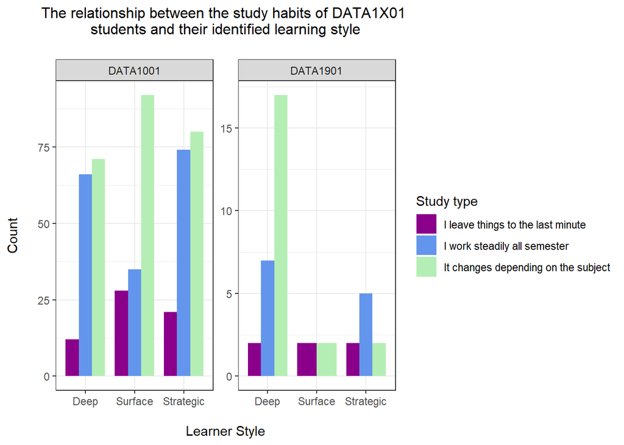

```r
# Code for bar plot
ggplot(data1, aes(x = learner_style, fill = study_type)) +
  geom_bar(position = 'dodge', width = 0.8) +
  labs(title = 'The relationship between the study habits of DATA1X01 \nstudents and their identified learning style\n', x = '\nLearner Style', y = 'Count\n', fill = 'Study type') +
  theme_minimal() +
  scale_fill_manual(values = c('darkmagenta','cornflowerblue','darkseagreen2')) + facet_wrap(~data1$mainstream_advanced, scales = 'free') + scale_x_discrete(labels = c('Deep','Surface','Strategic')) +
  theme_bw()+
  theme(plot.title = element_text(hjust = 0.5)) +
  theme(plot.title = element_text(size = 12))
```

### How do student mark goals from different DATA1X01 streams (DATA1001/DATA1901) correlate to the hours that the students hope to spend studying each week?

A weak correlation between DATA1X01 students’ mark goals and intended weekly study hours is evident. Data points are randomly scattered about the regression line. Near zero correlation coefficients (DATA1001: 0.08, DATA1901: -0.021) indicate no discernible variable association. However, the residual plots for DATA1X01 suggest constant variance. Despite slightly uneven DATA1001 point distributions, both residuals are generally homoscedastic. Nonetheless, the lack of visual linearity in the scatterplot indicates a linear fit is inappropriate.

Advanced students exhibit a narrower mark range (70-100 vs. 50-100), and smaller variation for intended study hours per mark goal. Academic confidence and expectations could be causal. However, the smaller sample size of DATA1901 diminishes the reliability of this conclusion. Response bias and estimation error further influences interpretations.

Regression analysis reveals no relationship between students’ self-predicted study hours and mark goals. Students’ desired marks are not strongly aligned with their perceived need for more (or less) study. Factors such as study efficiency, prior knowledge, or external resources may be more influential. Stronger relationships may emerge between *final* grades and *logged* study hours.

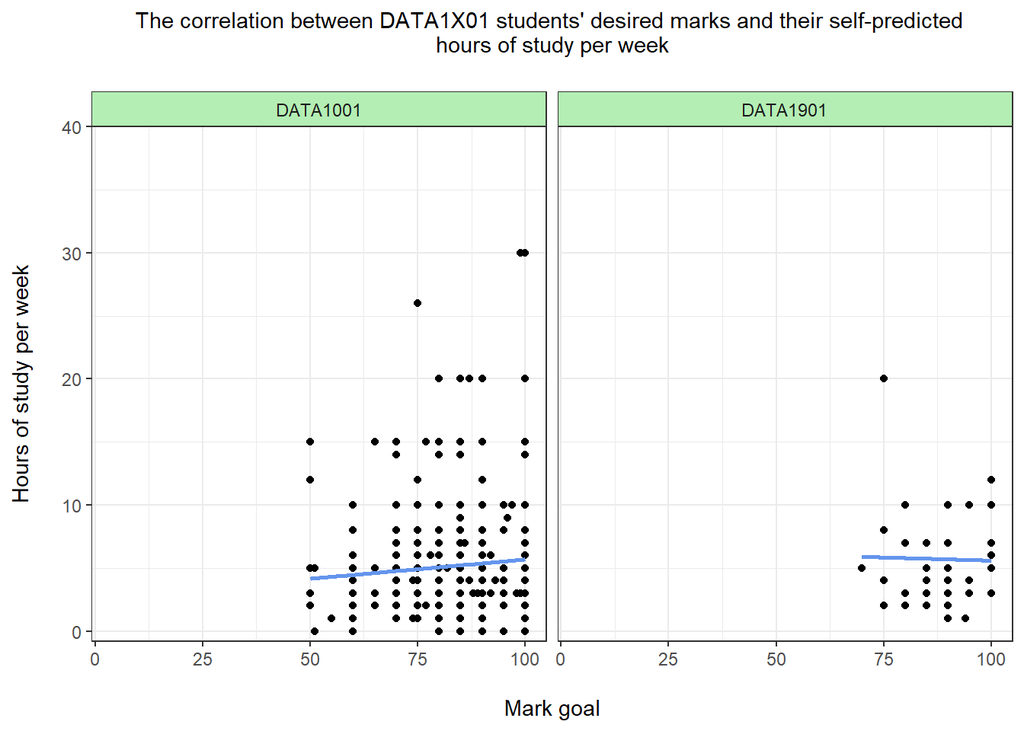

```r
# Filter data by stream for faceting
data1001 = filter(data1, mainstream_advanced == 'DATA1001')
data1901 = filter(data1, mainstream_advanced == 'DATA1901')

# Linear model
ggplot(data1, aes(x = mark_goal, y = hours_studying)) +
  geom_point(shape = 16, size = 1.5) +
  labs(x = '\nMark goal', y = 'Hours of study per week\n', title ='The correlation between DATA1X01 students\' desired marks and their self-predicted \nhours of study per week\n') +
  facet_wrap(~data1$mainstream_advanced) +
  coord_cartesian(expand = FALSE, xlim = c(-0.8, 105), ylim = c(-0.8, 40)) + geom_smooth(method="lm", se=FALSE, colour = 'cornflowerblue') + theme_bw() +
  theme(strip.background =element_rect(fill="darkseagreen2")) +
  theme(plot.title = element_text(size = 11)) +
  theme(plot.title = element_text(hjust = 0.5))
```

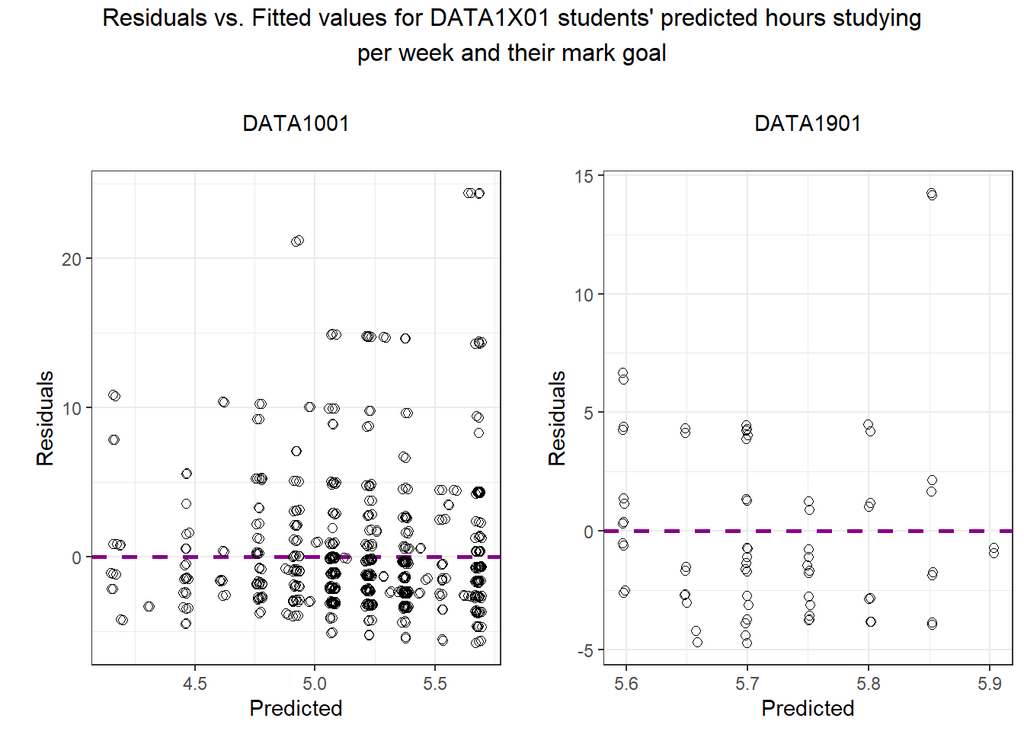

```r
# Correlation coefficient
# round(cor(data1001$mark_goal, data1001$hours_studying), 3)
# round(cor(data1901$mark_goal, data1901$hours_studying), 3)

# Residual plots
model = lm(hours_studying~mark_goal, data = data1001)
model2 = lm(hours_studying~mark_goal, data = data1901)

##DATA1001
plot1 =ggplot(lm(hours_studying~mark_goal, data = data1001), aes(x = .fitted, y = .resid)) +
  geom_point(shape = 1, size = 2) +
  geom_hline(yintercept = 0, linetype = "dashed", colour = "darkmagenta", linewidth = 0.9) +
  geom_jitter(width = 0.015, height = 0.1, shape = 1, size = 2) + theme_bw() + labs(x = 'Predicted', y ='\nResiduals')+theme(plot.title = element_text(hjust = 0.5)) + theme(plot.title = element_text(size = 11)) + labs(title = 'DATA1001\n')

##DATA1901
plot2 = ggplot(model2, aes(x = .fitted, y = .resid)) +
  geom_point(shape = 1, size = 2) +
  geom_hline(yintercept = 0, linetype = "dashed", colour = "darkmagenta", linewidth = 0.9) +
  geom_jitter(width = 0.0015, height = 0.5, shape = 1, size = 2) + theme_bw() + labs(x = 'Predicted', y = '\nResiduals') + theme(plot.title = element_text(hjust = 0.5)) + theme(plot.title = element_text(size = 11)) + labs(title = 'DATA1901\n')

#Arrangement of Residual Plots
grid.arrange(plot1,plot2, nrow = 1, top = "Residuals vs. Fitted values for DATA1X01 students' predicted hours studying\nper week and their mark goal\n")
```

### Articles

Despite differing demographics, research supports the positive correlations between ‘surface learning’ and ‘cramming’ (Bickerdike et al., 2016), and between ‘deep’ approaches and organised studying (Mattick et al., 2004).

The relationship between study hours and grades remains inconclusive (Gortner & Zalauf, 2000; Michaels & Miethe, 1989; Schuman et al., 1985) as with our estimated data, suggesting the influence of additional factors.

Academics are instead associated with study approaches and leaner styles (Bentil, 2023; Delgado et al., 2018).

#### References

- Bentil, J. (2023). Study habits and academic performance among public junior high school students in the Ekumfi District: investigating the controlling effect of learning styles. *European Journal of Social Sciences Studies, 8*(6). http://dx.doi.org/10.46827/ejsss.v8i6.1505
- Bickerdike, A., O’Deasmhunaigh, C., O’Flynn, S., & O’Tuathaigh, C. (2016). Learning strategies, study habits and social networking activity of undergraduate medical students. *International journal of medical education, 7*, 230–236. https://doi.org/10.5116/ijme.576f.d074
- Delgado, Á. H. A., Almeida, J. P. R., Mendes, L. S. B., Oliveira, I. N., Ezequiel, O. D. S., Lucchetti, A. L. G., & Lucchetti, G. (2018). Are surface and deep learning approaches associated with study patterns and choices among medical students? A cross-sectional study. *Sao Paulo medical journal = Revista paulista de medicina, 136*(5), 414–420. https://doi.org/10.1590/1516-3180.2018.0200060818
- Gortner Lahmers, A., & Zulauf, C. R. (2000). Factors associated with academic time use and academic performance of college students: A recursive approach. *Journal of College Student Development, 41*(5), 544–556. https://psycnet.apa.org/record/2000-00569-007
- Mattick, K., Dennis, I., & Bligh, J. (2004). Approaches to learning and studying in medical students: validation of a revised inventory and its relation to student characteristics and performance. *Medical education, 38*(5), 535–543. https://doi.org/10.1111/j.1365-2929.2004.01836.x
- Michaels, J., & Miethe, T. (1989). Academic effort and college grades. *Social Forces, 68*(1), 309 - 319. https://doi.org/10.1093/sf/68.1.309
- Schuman, H., Walsh, E., Olson, C., & Etheridge, B. (1985). Effort and reward: The assumption that college grades are affected by quantity of study. *Social Force, 63*(4), 945 - 966. https://doi.org/10.1093/sf/63.4.945

## Acknowledgements

#### Group meetings

15/08, 10 am - 12 pm : Full attendance (Research Question Proposal)

22/08, 10 am - 12 pm : Full attendance (IDA)

29/08, 10 am - 12 pm : Full attendance, excluding Ximena from illness (Research Questions 1 & 2)

05/09, 10 am - 12 pm : Full attendance (Articles & Executive Summary)

12/09, 10 am - 12 pm : Full attendance (Final Touches, Referencing & Acknowledgements)

#### Contributors

Fiona - Report Writing (IDA, RQ2, RQ2 Article), Coding (Plots), Editing

Ximena - Report Writing (IDA, References, Executive summary), Coding (Data Cleaning)

Long - Report Writing (IDA, RQ1), Slide Design

Khanh - Report Writing (IDA, RQ1 Article)

Evelynn - Report Writing (IDA, RQ1, Ethical Principles)

Vivian - Report Writing (IDA, RQ2, References)

#### Resources

- Alboukadel. (2019, December 25). *GGPLOT Point Shapes Best Tips*. Datanovia. https://www.datanovia.com/en/blog/ggplot-point-shapes-best-tips/#:~:text=Scatter%20plot%20with%20multiple%20groups,-It’s%20also%20possible&text=In%20this%20case%2C%20ggplot2%20will,to%20change%20manually%20point%20colors
- alexkoningham. (2017). *Request: multiple colours for facet strip.background #2096*. GitHub. https://github.com/tidyverse/ggplot2/issues/2096
- Auguie, B. (2017, September 9). *Arranging multiple grobs on a page*. https://cran.r-project.org/web/packages/gridExtra/vignettes/arrangeGrob.html
- Auguié, B. (2019, July 13). *Laying out multiple plots on a page*. https://cran.r-project.org/web/packages/egg/vignettes/Ecosystem.html
- B, D. (2010). *Set R plots x axis to show at y=0*. Stack Overflow. https://stackoverflow.com/questions/3422203/set-r-plots-x-axis-to-show-at-y-0
- *Change font size in quarto PDF*. (n.d.). Stack Overflow. https://stackoverflow.com/questions/74300829/change-font-size-in-quarto-pdf
- Chang, W. (2024, April 7). *3.6 Adjusting Bar Width and Spacing | R Graphics Cookbook, 2nd edition*. https://r-graphics.org/recipe-bar-graph-adjust-width
- *Deep, surface and strategic learning*. (n.d.). Teaching & Learning. https://spark.scu.edu.au/kb/tl/teach/focus-on-learning/deep-surface-and-strategic-learning
- GeeksforGeeks. (2021, November 5). *How To Customize Border in facet plot in ggplot2 in R*. GeeksforGeeks. https://www.geeksforgeeks.org/how-to-customize-border-in-facet-plot-in-ggplot2-in-r/
- Holtz, Y. (n.d.). *Dealing with color in ggplot2 | the R Graph Gallery*. https://r-graph-gallery.com/ggplot2-color.html
- *HTML theming*. (n.d.). Quarto. https://quarto.org/docs/output-formats/html-themes.html
- *Jitter points to avoid overplotting*. (n.d.). https://ggplot2.tidyverse.org/reference/position_jitter.html
- John. (2010). *Set the plot title to wrap around and shrink the text to fit the plot*. Stack Overflow. https://stackoverflow.com/questions/2631780/set-the-plot-title-to-wrap-around-and-shrink-the-text-to-fit-the-plot
- John, C. (2016). *Center Plot title in ggplot2*. Stack Overflow. https://stackoverflow.com/questions/40675778/center-plot-title-in-ggplot2
- kdarris. (2015). *How to plot multiple LME residual plots in one device*. Stack Overflow. https://stackoverflow.com/questions/29121372/how-to-plot-multiple-lme-residual-plots-in-one-device
- *Keep rows that match a condition*. (n.d.). https://dplyr.tidyverse.org/reference/filter.html
- *Markdown cheat Sheet*. (n.d.). https://www.markdownguide.org/cheat-sheet/
- Mike. (2022). *Standard column width in facetted and grouped ggplot bar plot*. Stack Overflow. https://stackoverflow.com/questions/71253379/standard-column-width-in-facetted-and-grouped-ggplot-bar-plot
- Nelamali, N. (2022). *How to Replace Values in R with Examples*. Spark by {Examples}. https://sparkbyexamples.com/r-programming/replace-values-in-r/amp/
- Rinker, T. (2011). *move axis labels ggplot*. Stack Overflow. https://stackoverflow.com/questions/8454243/move-axis-labels-ggplot
- R Markdown Syntax: Headings & Lists*. (n.d.). Data Carpentry. https://ucsbcarpentry.github.io/R-markdown/03-headings-lists/index.html#:~:text=Creating%20Headings%20and%20Subheadings&text=We%20can%20insert%20headings%20and,and%206%20being%20the%20smallest.
- Telkamp, B. (2017). *Change color of bars in facetted bar plot*. Stack Overflow. https://stackoverflow.com/questions/46874045/change-color-of-bars-in-facetted-bar-plot
- Virginia Tech: Department of Statistics. (2019.). *Introduction to R markdown*. https://rstudio-pubs-static.s3.amazonaws.com/526618_c9877468bcc24c40a5f460e2f5e6beb6.html#:~:text=Unordered%20Bullet%20Lists&text=Each%20item%20in%20the%20list,twice%20from%20the%20last%20indent.
- Wade, J. (2017). *How to change factor names on x axis with ggplot2 and R?* Stack Overflow. https://stackoverflow.com/questions/42845262/how-to-change-factor-names-on-x-axis-with-ggplot2-and-r

#### Ed Discussion

[Linear Graphing](https://edstem.org/au/courses/16787/discussion/2186111)

[Linear Fits](https://edstem.org/au/courses/16787/discussion/2187207)

[Final Questions](https://edstem.org/au/courses/16787/discussion/2220540)

[Professional Standard of Report](https://edstem.org/au/courses/16787/discussion/2215629)

#### Drop-in Sessions

02/09, 3 pm - 5 pm: Drop-in Session with Elyna and Cosette (Facetting and plotting)

11/09, 3 pm - 5 pm: Drop-in Session with Shreya and Joshua (Linear relationship & general questions)

13/09, 3 pm- 5 pm: Drop-in Session with Shreya (Research definition advice & HTML help)

### Declaration on Professional Ethics

This report adheres to the International Statistics Institute’s shared professional value of integrity by being transparent about the methodologies used and the results. We also ensured that bias was limited in data analysis and presentation. All external information sources used in the report were acknowledged accordingly.

The ethical principle of maintaining confidence in statistics was upheld by ensuring accurate descriptions of our results, as well as establishing some limitations of the data to the user.